# Project Python Foundations: FoodHub Data Analysis

### **Question 12**: Perform a multivariate analysis to explore relationships between the important variables in the dataset. (It is a good idea to explore relations between numerical variables as well as relations between numerical and categorical variables) [10 marks]

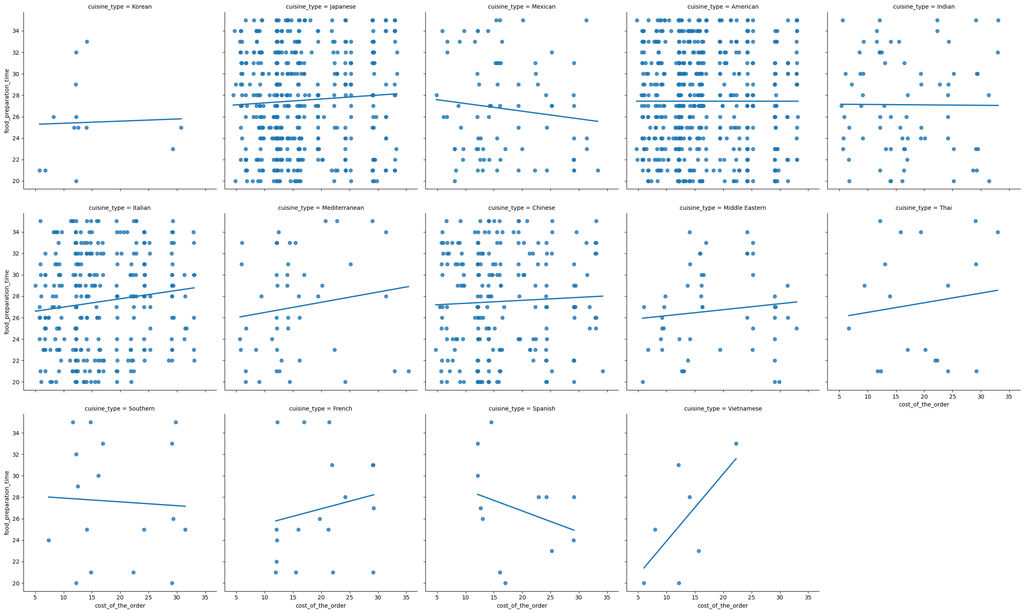

```python
# Relative scatterplots to visualize the relationship between the cost of the order
# sns.relplot(data=df, x = 'cost_of_the_order', y='food_preparation_time', col='cuisine_type', kind='scatter', col_wrap=5)
sns.lmplot(df, x = 'cost_of_the_order', y='food_preparation_time', col='cuisine_type', col_wrap=5, ci=None) # This allows us to add a line of best fit to each of the relations, since relplot does not allow us to
```

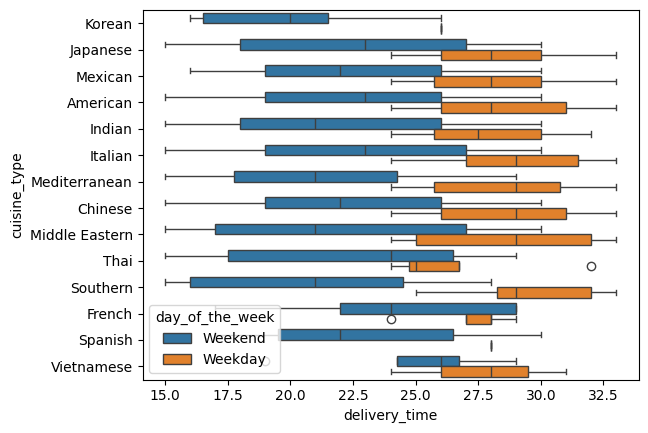

```python
sns.boxplot(df, x='delivery_time', y='cuisine_type', hue='day_of_the_week')
```

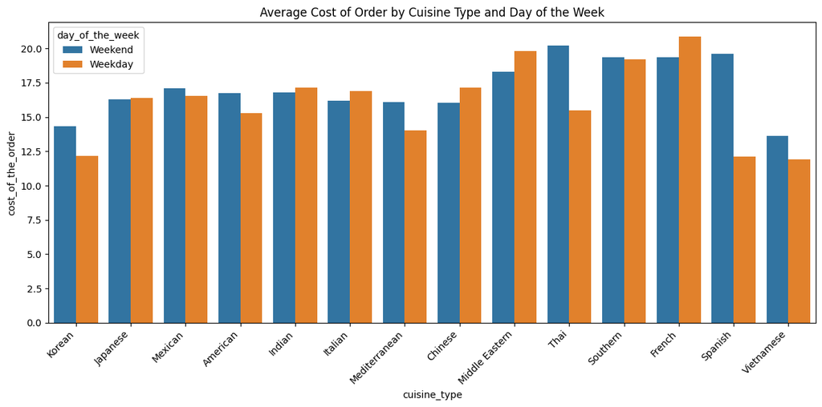

```python
# Grouped bar plot for average cost of order by cuisine type and day of the week
plt.figure(figsize=(12, 6))
sns.barplot(data=df, x='cuisine_type', y='cost_of_the_order', hue='day_of_the_week', ci=None)
plt.title('Average Cost of Order by Cuisine Type and Day of the Week')
plt.xticks(rotation=45, ha='right')
plt.tight_layout()
plt.show()
```

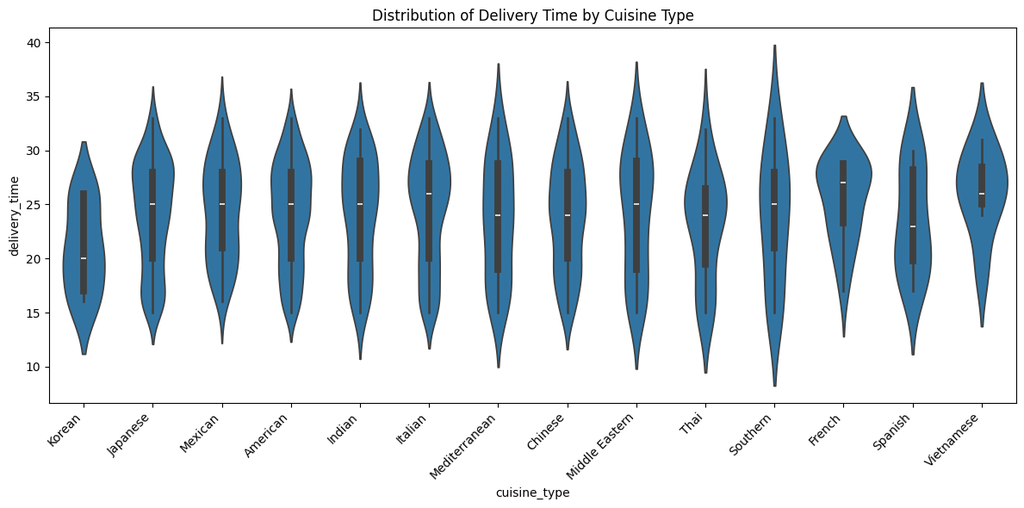

```python
# Violin plot for delivery time distribution by cuisine type
plt.figure(figsize=(12, 6))
sns.violinplot(data=df, x='cuisine_type', y='delivery_time')
plt.title('Distribution of Delivery Time by Cuisine Type')
plt.xticks(rotation=45, ha='right')
plt.tight_layout()
plt.show()
```

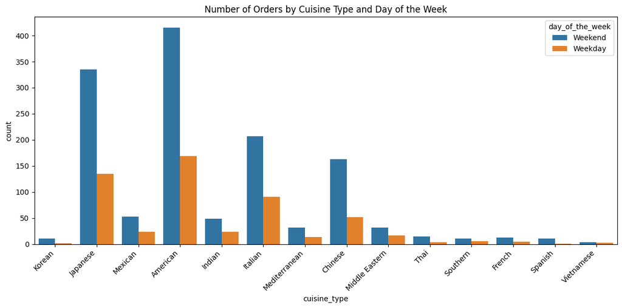

```python
# Countplot of cuisine type by day of the week
plt.figure(figsize=(12, 6))
sns.countplot(data=df, x='cuisine_type', hue='day_of_the_week')
plt.title('Number of Orders by Cuisine Type and Day of the Week')
plt.xticks(rotation=45, ha='right')
plt.tight_layout()
plt.show()
```

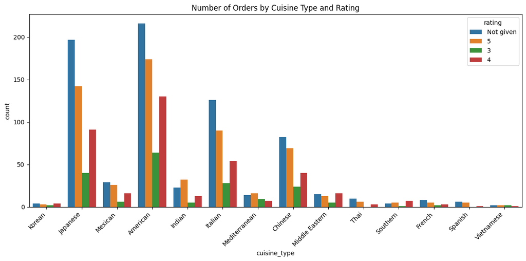

```python
# Countplot of cuisine type by rating
plt.figure(figsize=(12, 6))
sns.countplot(data=df, x='cuisine_type', hue='rating')
plt.title('Number of Orders by Cuisine Type and Rating')
plt.xticks(rotation=45, ha='right')
plt.tight_layout()
plt.show()
```

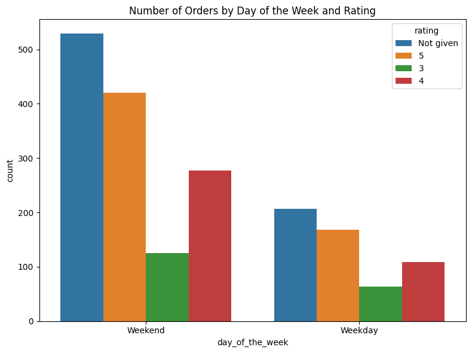

```python
# Countplot of day of the week by rating
plt.figure(figsize=(8, 6))
sns.countplot(data=df, x='day_of_the_week', hue='rating')
plt.title('Number of Orders by Day of the Week and Rating')
plt.tight_layout()
plt.show()
```

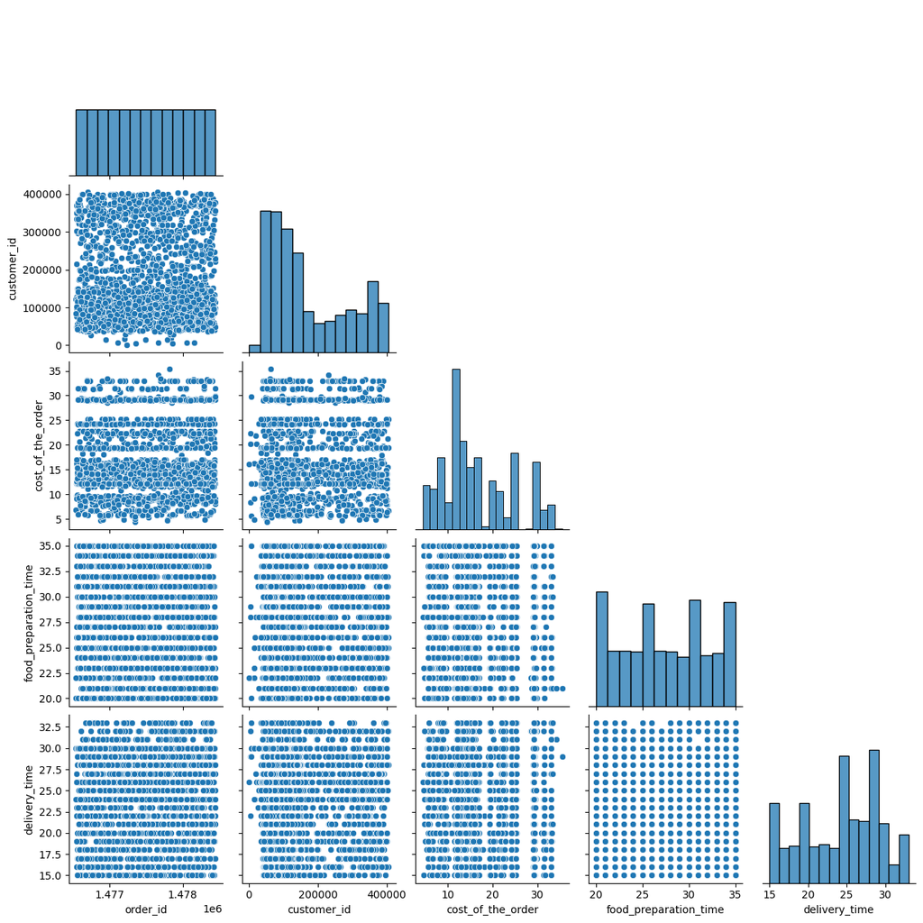

```python
# Putting this pairplot here as well as this does also work for a multivirate analysis
sns.pairplot(df, corner=True)
```

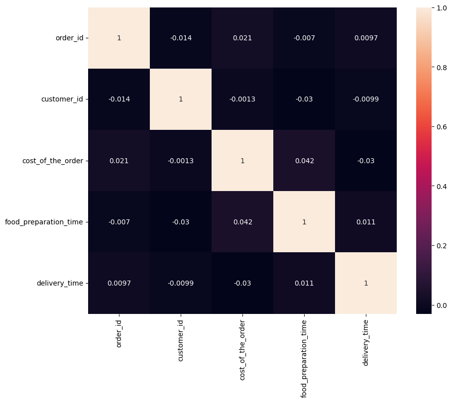

```python
# Putting this heatplot here as well as this does also work for a multivirate analysis
plt.figure(figsize=(10, 8))
sns.heatmap(df.corr(numeric_only=True), annot=True)
```

### **Question 13:** The company wants to provide a promotional offer in the advertisement of the restaurants. The condition to get the offer is that the restaurants must have a rating count of more than 50 and the average rating should be greater than 4. Find the restaurants fulfilling the criteria to get the promotional offer. [3 marks]

```python
df['rating'].unique()

df['rating'] = df['rating'].replace('Not given', np.nan)
df['rating'] = pd.to_numeric(df['rating'])

# df.info()

# This line here will allow us to filter for all the restaurants with a rating over 4 and group by the restaurant names for the total ratings.
# We use .count() here since it will count only the valid entires, which we know is only 1162 after converting the column to a numeric column, since it originally came as a object column
greater_than_4_restaurants = df[df['rating']>4].groupby('restaurant_name')['rating'].count().reset_index(name='rating_count')

# Here, we are using the newly created rating_count column and filtering down to only the restaurants that have over 50 ratings
restaurants_over_50 = greater_than_4_restaurants[greater_than_4_restaurants['rating_count']>50]
# print(restaurants_over_50)

# Here, we are merging the new restaurants_over_50 dataframe with df using the "restaurant_name" column, and then immediately creating a new dataframe that creates an average rating column.
# This allows us to figure out the true average rating of all the restaurants
merge_dfrestaurants = pd.merge(df, restaurants_over_50['restaurant_name'], on='restaurant_name', how='inner')
average_rating = merge_dfrestaurants.groupby('restaurant_name')['rating'].mean().reset_index(name='average_rating')
# print(average_rating)

# This final step has us merging all the relevant dataframes, which in this case is the dataframes related to the average values and over 50 rating count dataframes
# By doing this on the shared column "restaurant_name", the new qualified_restaurants dataframe will only include the rows that have values present in both the merging dataframes
qualified_restaurants = pd.merge(restaurants_over_50, average_rating, on='restaurant_name', how='inner')
print(qualified_restaurants)
```

```
     restaurant_name  rating_count  average_rating
0        Shake Shack            60        4.278195
1  The Meatball Shop            53        4.511905
```

### **Question 14:** The company charges the restaurant 25% on the orders having cost greater than 20 dollars and 15% on the orders having cost greater than 5 dollars. Find the net revenue generated by the company across all orders. [3 marks]

```python
# Write the code here

# 'cost_of_the_order' > 20 = 25% increase, then add up the total for this
# 'cost_of_the_order' > 5 = 15% increase, then add up the total for this
# add both totals to net_revenue

# This column will allow us to see the total price with the markup
df['total_cost_with_markup'] = np.where(df['cost_of_the_order']>20, df['cost_of_the_order']*1.25, np.where(df['cost_of_the_order']>5, df['cost_of_the_order']*1.15, df['cost_of_the_order']))

# This column will gives us the total revenue the company makes per order
df['net_revenue'] = df['total_cost_with_markup'] - df['cost_of_the_order']

# Total sum of the revenue the company makes
net_revenue = df['net_revenue'].sum()

print('We can see that the net revenue the company generates is $', round(net_revenue, 3), sep='')

df.head()
```

```
We can see that the net revenue the company generates is $6166.303
```

|  | order_id | customer_id | restaurant_name | cuisine_type | cost_of_the_order | day_of_the_week | rating | food_preparation_time | delivery_time | total_cost_with_markup | net_revenue |
| --- | --- | --- | --- | --- | --- | --- | --- | --- | --- | --- | --- |
| 0 | 1477147 | 337525 | Hangawi | Korean | 30.75 | Weekend | NaN | 25 | 20 | 38.4375 | 7.6875 |
| 1 | 1477685 | 358141 | Blue Ribbon Sushi Izakaya | Japanese | 12.08 | Weekend | NaN | 25 | 23 | 13.8920 | 1.8120 |
| 2 | 1477070 | 66393 | Cafe Habana | Mexican | 12.23 | Weekday | 5.0 | 23 | 28 | 14.0645 | 1.8345 |
| 3 | 1477334 | 106968 | Blue Ribbon Fried Chicken | American | 29.20 | Weekend | 3.0 | 25 | 15 | 36.5000 | 7.3000 |
| 4 | 1478249 | 76942 | Dirty Bird to Go | American | 11.59 | Weekday | 4.0 | 25 | 24 | 13.3285 | 1.7385 |

#### Observations: We can see that in total, with the markups the company charges, they are making a total of $6166.30 dollars in net revenue

### **Question 15:** The company wants to analyze the total time required to deliver the food. What percentage of orders take more than 60 minutes to get delivered from the time the order is placed? (The food has to be prepared and then delivered.) [2 marks]

```python
# Write the code here

# Here, we are going to use the columns "Food_preparation_time" and "delivery_time", add the values in the columns together, and create a new column called "total_required_time".
# Then after doing that, we shall find all the orders that take over 60 minutes to deliver, and convert that to a percentage (similar method as in Q9 can be done here)

df['total_required_time'] = df['food_preparation_time'] + df['delivery_time']
orders_over_60 = df[df['total_required_time']>60].shape[0] # We use .shape[0] here since we are trying to know the total amount of rows that have a total delivery time over 60 minutes
print('There are', orders_over_60, 'orders that take over 60 minutes to get delivered after being placed')
print('We know the total amount of orders is', len(df['total_required_time']))
percentage_over_60 = (df[df['total_required_time']>60].shape[0]/len(df['total_required_time']))*100
print('Therefore, the total percentage of orders over 60 minutes is', percentage_over_60, '\nAfter rounding, the percentage is ', round(percentage_over_60,2), '%', sep='')
```

```
There are 200 orders that take over 60 minutes to get delivered after being placed
We know the total amount of orders is 1898
Therefore, the total percentage of orders over 60 minutes is10.537407797681771
After rounding, the percentage is 10.54%
```

#### Observations: We can see that the total percentage of orders over 60 minutes is around 10.54% of the orders

### **Question 16:** The company wants to analyze the delivery time of the orders on weekdays and weekends. How does the mean delivery time vary during weekdays and weekends? [2 marks]

```python
# Write the code here

df.groupby('day_of_the_week')['delivery_time'].mean().round(3)
```

| day_of_the_week | delivery_time |
| --- | --- |
| Weekday | 28.34 |
| Weekend | 22.47 |

**dtype:** float64

### Recommendations:

- Due to the lack of people ordering them, I would recommend removing the following cuisine types:
  - Thai
  - Southern
  - French
  - Spanish
  - Vietnamese
  - Korean

  This could help with leveraging the cuisine popularity, and also allow for reducing total costs within the restaurants themselves
- Implement strategies to encourage more customers to rate their orders. This could include push notifications, in-app reminders, or small incentives. More ratings will provide valuable feedback for restaurants and the platform.
- Investigate the orders that take longer than 60 minutes for delivery. Identify bottlenecks in the process (food preparation or delivery) for these orders and work with restaurants and delivery personnel to reduce these times. This could involve setting stricter time targets or providing support for efficient order handling.

```python
#@title Convert ipynb to HTML in Colab
# Upload ipynb
from google.colab import files
f = files.upload()

# Convert ipynb to html
import subprocess
file0 = list(f.keys())[0]
_ = subprocess.run(["pip", "install", "nbconvert"])
_ = subprocess.run(["jupyter", "nbconvert", file0, "--to", "html"])

# download the html
files.download(file0[:-5]+"html")
```

[output not shown]